# 07

```python
import pandas as pd
import csv
```

```python
dfRecipes = pd.read_csv('csv/fit.recepty.csv')
dfProducts = pd.read_csv('csv/products.csv')
dfCategories = pd.read_csv('csv/out_categories.csv')
```

```python
dfProducts.rename(columns={'primary_category.id': 'cat_id'}, inplace=True)
dfCategories.rename(columns={'category_id' : 'cat_id'}, inplace=True)
```

```python
dfCategories.head()
```

|  | cat_id | category_path |
| --- | --- | --- |
| 0 | 300102026 | Ovoce a zelenina/Bylinky a koření |
| 1 | 300102000 | Ovoce a zelenina |
| 2 | 300102027 | Ovoce a zelenina/Bylinky a koření/Řezané |
| 3 | 300102001 | Ovoce a zelenina/Ovoce |
| 4 | 300102039 | Ovoce a zelenina/Ovoce/Bio ovoce |

## Joiny

Joiny sa pouzivaju na kombinovanie riadkov z 2 alebo viacerych tabuliek na zaklade spolocneho identifikatora medzi nimi.

**Typy joinov**

- Inner join
- Left join
- Right join
- Outer join

## Inner join

Inner join spoji vsetky riadky z oboch tabuliek, kde sa nachadza zhoda v jednej aj v druhej tabulke. Inner join je to iste ako zapis join.

[figure not shown]

**Priklad** Prepojenie produktov a kategorii produktov. Inner join vrati zoznam produktov, ktore maju pridelenu kategoriu. Ak su v tabulke produktov, zaznamy, ktore kategoriu priradenu nemaju, tieto produkty vratene nebudu.

### SQL ukazka

SELECT *  
FROM "dfProducts" as df1  
INNER JOIN "dfCategories" as df2  
ON df1.cat_id = df2.cat_id;

```python
dfInnerJoin = pd.merge(dfProducts, dfCategories, on='cat_id')
```

```python
dfInnerJoin
```

|  | badge | brand_name | categories | country_of_origin | crc32 | description | id | image | image_large | ingredients | ... | price_currency | price_for_bottle.amount | price_for_bottle.currency | price_for_unit_amount | price_for_unit_currency | cat_id | unit | weight | weight_variations | category_path |
| --- | --- | --- | --- | --- | --- | --- | --- | --- | --- | --- | --- | --- | --- | --- | --- | --- | --- | --- | --- | --- | --- |
| 0 | NaN | Nivea | [{'id': 300109000}, {'id': 300109103}, {'id': ... | dle aktuální nabídky | 4119786657 | Nivea Sprej antiperspirant Silver Protect Dyna... | 1296725 | https://1564005101.rsc.cdn77.org/images/grocer... | https://1564005101.rsc.cdn77.org/images/grocer... | Butane\nIosbutane\nPropane\nCyclomethicone\nAl... | ... | CZK | NaN | NaN | 432,67 | CZK | 300109110.0 | l | NaN | False | Drogerie a kosmetika/Deodoranty a tělové sprej... |
| 1 | NaN | NaN | [{'id': 300109000}, {'id': 300109103}, {'id': ... | dle aktuální nabídky | 1164047169 | NaN | 1303675 | https://1564005101.rsc.cdn77.org/images/grocer... | https://1564005101.rsc.cdn77.org/images/grocer... | Alcohol denat.\nIsobutane\nPropane\nButane\nIs... | ... | CZK | NaN | NaN | 532,67 | CZK | 300109110.0 | l | NaN | False | Drogerie a kosmetika/Deodoranty a tělové sprej... |
| 2 | NaN | NaN | [{'id': 300109000}, {'id': 300109103}, {'id': ... | dle aktuální nabídky | 3495741254 | NaN | 1303677 | https://1564005101.rsc.cdn77.org/images/grocer... | https://1564005101.rsc.cdn77.org/images/grocer... | Alcohol denat.\nIsobutane\nPropane\nButane\nPa... | ... | CZK | NaN | NaN | 532,67 | CZK | 300109110.0 | l | NaN | False | Drogerie a kosmetika/Deodoranty a tělové sprej... |
| 3 | NaN | NaN | [{'id': 300109000}, {'id': 300109103}, {'id': ... | dle aktuální nabídky | 2911924383 | NaN | 1303681 | https://1564005101.rsc.cdn77.org/images/grocer... | https://1564005101.rsc.cdn77.org/images/grocer... | Alcohol denat.\nIsobutane\nPropane\nButane\nIs... | ... | CZK | NaN | NaN | 532,67 | CZK | 300109110.0 | l | NaN | False | Drogerie a kosmetika/Deodoranty a tělové sprej... |
| 4 | NaN | NaN | [{'id': 300109000}, {'id': 300109103}, {'id': ... | dle aktuální nabídky | 2097797367 | Antiperspirant sprej pro muže.\n\nBezpečnostní... | 1307193 | https://1564005101.rsc.cdn77.org/images/grocer... | https://1564005101.rsc.cdn77.org/images/grocer... | Butane\nIsobutane\nPropane\nAluminum chlorohyd... | ... | CZK | NaN | NaN | 466 | CZK | 300109110.0 | l | NaN | False | Drogerie a kosmetika/Deodoranty a tělové sprej... |
| 5 | NaN | NaN | [{'id': 134253}, {'id': 300109000}, {'id': 300... | dle aktuální nabídky | 2706881168 | Antiperspirant sprej pro muže. Bezpečnostní va... | 1307201 | https://1564005101.rsc.cdn77.org/images/grocer... | https://1564005101.rsc.cdn77.org/images/grocer... | Butane\nIsobutane\nPropane\nCyclopentasiloxane... | ... | CZK | NaN | NaN | 466 | CZK | 300109110.0 | l | NaN | False | Drogerie a kosmetika/Deodoranty a tělové sprej... |
| 6 | NaN | NaN | [{'id': 134253}, {'id': 300109000}, {'id': 300... | dle aktuální nabídky | 3446774679 | Antiperspirant sprej pro muže. Bezpečnostní va... | 1307215 | https://1564005101.rsc.cdn77.org/images/grocer... | https://1564005101.rsc.cdn77.org/images/grocer... | Butane\nIsobutane\nPropane\nAluminum chlorohyd... | ... | CZK | NaN | NaN | 466 | CZK | 300109110.0 | l | NaN | False | Drogerie a kosmetika/Deodoranty a tělové sprej... |
| 7 | NaN | NaN | [{'id': 134253}, {'id': 300109000}, {'id': 300... | dle aktuální nabídky | 108038283 | Antiperspirant sprej pro muže. Bezpečnostní va... | 1307221 | https://1564005101.rsc.cdn77.org/images/grocer... | https://1564005101.rsc.cdn77.org/images/grocer... | Butane\nIsobutane\nPropane\nAluminum chlorohyd... | ... | CZK | NaN | NaN | 466 | CZK | 300109110.0 | l | NaN | False | Drogerie a kosmetika/Deodoranty a tělové sprej... |
| 8 | NaN | NaN | [{'id': 300109000}, {'id': 300109103}, {'id': ... | dle aktuální nabídky | 2536318912 | Objevte 48 hodinovou dlouhotrvající deo ochran... | 1307893 | https://1564005101.rsc.cdn77.org/images/grocer... | https://1564005101.rsc.cdn77.org/images/grocer... | Butane\nAlcohol denat.\nPropane\nIsobutane\nTr... | ... | CZK | NaN | NaN | 366 | CZK | 300109110.0 | l | NaN | False | Drogerie a kosmetika/Deodoranty a tělové sprej... |
| 9 | NaN | NaN | [{'id': 300109000}, {'id': 300109103}, {'id': ... | dle aktuální nabídky | 3110451995 | Objevte až 72hodinovou silnou deo ochranu pro ... | 1307897 | https://1564005101.rsc.cdn77.org/images/grocer... | https://1564005101.rsc.cdn77.org/images/grocer... | Butane\nPropane\nAqua\nAluminum chlorohydrate\... | ... | CZK | NaN | NaN | 332,67 | CZK | 300109110.0 | l | NaN | False | Drogerie a kosmetika/Deodoranty a tělové sprej... |
| 10 | NaN | NaN | [{'id': 300109000}, {'id': 300109103}, {'id': ... | dle aktuální nabídky | 1730019137 | Objevte deodorant Fa Men Attraction Force s dl... | 1307899 | https://1564005101.rsc.cdn77.org/images/grocer... | https://1564005101.rsc.cdn77.org/images/grocer... | Butane\nAlcohol denat.\nPropane\nIsobutane\nTr... | ... | CZK | NaN | NaN | 366 | CZK | 300109110.0 | l | NaN | False | Drogerie a kosmetika/Deodoranty a tělové sprej... |
| 11 | NaN | NaN | [{'id': 300109000}, {'id': 300109103}, {'id': ... | dle aktuální nabídky | 2060185702 | Objevte smyslně svěží vůni deodorantu Fa Men D... | 1307901 | https://1564005101.rsc.cdn77.org/images/grocer... | https://1564005101.rsc.cdn77.org/images/grocer... | Butane\nAlcohol denat.\nPropane\nIsobutane\nTr... | ... | CZK | NaN | NaN | 366 | CZK | 300109110.0 | l | NaN | False | Drogerie a kosmetika/Deodoranty a tělové sprej... |
| 12 | NaN | NaN | [{'id': 300109000}, {'id': 300109103}, {'id': ... | dle aktuální nabídky | 3951328418 | Antiperspirant Fa Men Xtreme Polar s chladivým... | 1307903 | https://1564005101.rsc.cdn77.org/images/grocer... | https://1564005101.rsc.cdn77.org/images/grocer... | Butane, Propane, Cyclomethicone, Aluminum Chlo... | ... | CZK | NaN | NaN | 466 | CZK | 300109110.0 | l | NaN | False | Drogerie a kosmetika/Deodoranty a tělové sprej... |
| 13 | NaN | NaN | [{'id': 300109000}, {'id': 300109103}, {'id': ... | dle aktuální nabídky | 3462073540 | Antiperspirant Fa Men Xtreme Protect 5 nabízí ... | 1307907 | https://1564005101.rsc.cdn77.org/images/grocer... | https://1564005101.rsc.cdn77.org/images/grocer... | Butane, Propane, Cyclomethicone, Aluminum Chlo... | ... | CZK | NaN | NaN | 466 | CZK | 300109110.0 | l | NaN | False | Drogerie a kosmetika/Deodoranty a tělové sprej... |
| 14 | NaN | NaN | [{'id': 300109000}, {'id': 300109103}, {'id': ... | dle aktuální nabídky | 2701918087 | Antiperspirant Invisible Power pro 72hodinovou... | 1307909 | https://1564005101.rsc.cdn77.org/images/grocer... | https://1564005101.rsc.cdn77.org/images/grocer... | Butane\nPropane\nAqua\nAluminum chlorohydrate\... | ... | CZK | NaN | NaN | 466 | CZK | 300109110.0 | l | NaN | False | Drogerie a kosmetika/Deodoranty a tělové sprej... |
| 15 | NaN | NaN | [{'id': 300109000}, {'id': 300109103}, {'id': ... | dle aktuální nabídky | 1385161795 | Antiperspirant Fa Men Xtreme Sports - 72hodino... | 1307911 | https://1564005101.rsc.cdn77.org/images/grocer... | https://1564005101.rsc.cdn77.org/images/grocer... | Butane\nPropane\nCyclomethicone\nAluminum chlo... | ... | CZK | NaN | NaN | 466 | CZK | 300109110.0 | l | NaN | False | Drogerie a kosmetika/Deodoranty a tělové sprej... |
| 16 | NaN | NaN | [{'id': 300109000}, {'id': 300109103}, {'id': ... | dle aktuální nabídky | 3498178885 | UPOZORNĚNÍ: Před použitím protřepat. Aplikujte... | 1308185 | https://1564005101.rsc.cdn77.org/images/grocer... | https://1564005101.rsc.cdn77.org/images/grocer... | Butane\nIsobutane\nPropane\nAluminum chlorohyd... | ... | CZK | NaN | NaN | 466 | CZK | 300109110.0 | l | NaN | False | Drogerie a kosmetika/Deodoranty a tělové sprej... |
| 17 | NaN | NaN | [{'id': 300109000}, {'id': 300109103}, {'id': ... | Velká Británie | 2579246222 | Nebezpečí\nExtrémně hořlavý aerosol.\n\nUPOZOR... | 1312351 | https://1564005101.rsc.cdn77.org/images/grocer... | https://1564005101.rsc.cdn77.org/images/grocer... | Butane\nIsobutane\nPropane\nAluminum chlorohyd... | ... | CZK | NaN | NaN | 499,33 | CZK | 300109110.0 | l | NaN | False | Drogerie a kosmetika/Deodoranty a tělové sprej... |
| 18 | NaN | NaN | [{'id': 300109000}, {'id': 300109103}, {'id': ... | Velká Británie | 112018558 | Intenzivní ochrana\nPomáhá chránit proti podrá... | 1312895 | https://1564005101.rsc.cdn77.org/images/grocer... | https://1564005101.rsc.cdn77.org/images/grocer... | Butane\nIsobutane\nPropane\nAluminum chlorohyd... | ... | CZK | NaN | NaN | 532,67 | CZK | 300109110.0 | l | NaN | False | Drogerie a kosmetika/Deodoranty a tělové sprej... |
| 19 | NaN | NaN | [{'id': 300109000}, {'id': 300109103}, {'id': ... | Velká Británie | 31668473 | UPOZORNĚNÍ: Před použitím protřepat. Aplikujte... | 1312935 | https://1564005101.rsc.cdn77.org/images/grocer... | https://1564005101.rsc.cdn77.org/images/grocer... | Butane\nIsobutane\nPropane\nAluminum chlorohyd... | ... | CZK | NaN | NaN | 359,6 | CZK | 300109110.0 | l | NaN | False | Drogerie a kosmetika/Deodoranty a tělové sprej... |
| 20 | NaN | NaN | [{'id': 300109000}, {'id': 300109103}, {'id': ... | Velká Británie | 3325362378 | UPOZORNĚNÍ: Před použitím protřepat. Aplikujte... | 1312943 | https://1564005101.rsc.cdn77.org/images/grocer... | https://1564005101.rsc.cdn77.org/images/grocer... | NaN | ... | CZK | NaN | NaN | 466 | CZK | 300109110.0 | l | NaN | False | Drogerie a kosmetika/Deodoranty a tělové sprej... |
| 21 | NaN | NaN | [{'id': 300109000}, {'id': 300109103}, {'id': ... | Velká Británie | 622339322 | UPOZORNĚNÍ: Před použitím protřepat. Aplikujte... | 1312945 | https://1564005101.rsc.cdn77.org/images/grocer... | https://1564005101.rsc.cdn77.org/images/grocer... | Butane\nIsobutane\nPropane\nAluminum chlorohyd... | ... | CZK | NaN | NaN | 359,6 | CZK | 300109110.0 | l | NaN | False | Drogerie a kosmetika/Deodoranty a tělové sprej... |
| 22 | NaN | NaN | [{'id': 300109000}, {'id': 300109103}, {'id': ... | Velká Británie | 2316672247 | Aplikujte přímo na pokožku ve vzdálenosti 15 c... | 1314145 | https://1564005101.rsc.cdn77.org/images/grocer... | https://1564005101.rsc.cdn77.org/images/grocer... | Alcohol denat.\nButane\nIsobutane\nPropane\nPa... | ... | CZK | NaN | NaN | 599,33 | CZK | 300109110.0 | l | NaN | False | Drogerie a kosmetika/Deodoranty a tělové sprej... |
| 23 | NaN | NaN | [{'id': 300109000}, {'id': 300109103}, {'id': ... | Velká Británie | 1747656348 | Aplikujte přímo na pokožku ve vzdálenosti 15 c... | 1314149 | https://1564005101.rsc.cdn77.org/images/grocer... | https://1564005101.rsc.cdn77.org/images/grocer... | Alcohol denat.\nButane\nIsobutane\nPropane\nPa... | ... | CZK | NaN | NaN | 532,67 | CZK | 300109110.0 | l | NaN | False | Drogerie a kosmetika/Deodoranty a tělové sprej... |
| 24 | NaN | NaN | [{'id': 300109000}, {'id': 300109103}, {'id': ... | Velká Británie | 2561545720 | Aplikujte přímo na pokožku ve vzdálenosti 15 c... | 1314153 | https://1564005101.rsc.cdn77.org/images/grocer... | https://1564005101.rsc.cdn77.org/images/grocer... | Butane\nIsobutane\nPropane\nCyclopentasiloxane... | ... | CZK | NaN | NaN | 599,33 | CZK | 300109110.0 | l | NaN | False | Drogerie a kosmetika/Deodoranty a tělové sprej... |
| 25 | NaN | NaN | [{'id': 300109000}, {'id': 300109103}, {'id': ... | Velká Británie | 3849728602 | Aplikujte přímo na pokožku ve vzdálenosti 15 c... | 1314155 | https://1564005101.rsc.cdn77.org/images/grocer... | https://1564005101.rsc.cdn77.org/images/grocer... | Butane\nIsobutane\nPropane\nCyclopentasiloxane... | ... | CZK | NaN | NaN | 599,33 | CZK | 300109110.0 | l | NaN | False | Drogerie a kosmetika/Deodoranty a tělové sprej... |
| 26 | NaN | NaN | [{'id': 300109000}, {'id': 300109103}, {'id': ... | Velká Británie | 1522931044 | Aplikujte přímo na pokožku ve vzdálenosti 15 c... | 1314157 | https://1564005101.rsc.cdn77.org/images/grocer... | https://1564005101.rsc.cdn77.org/images/grocer... | Butane\nIsobutane\nPropane\nCyclopentasiloxane... | ... | CZK | NaN | NaN | 599,33 | CZK | 300109110.0 | l | NaN | False | Drogerie a kosmetika/Deodoranty a tělové sprej... |
| 27 | NaN | NaN | [{'id': 300109000}, {'id': 300109103}, {'id': ... | Velká Británie | 3012125861 | Aplikujte přímo na pokožku ve vzdálenosti 15 c... | 1314159 | https://1564005101.rsc.cdn77.org/images/grocer... | https://1564005101.rsc.cdn77.org/images/grocer... | Alcohol denat.\nButane\nIsobutane\nPropane\nPa... | ... | CZK | NaN | NaN | 599,33 | CZK | 300109110.0 | l | NaN | False | Drogerie a kosmetika/Deodoranty a tělové sprej... |
| 28 | NaN | NaN | [{'id': 300109000}, {'id': 300109103}, {'id': ... | Holandsko | 3341698103 | Antiperspirant deodorant sprej Dove Men+Care I... | 1291201 | https://1564005101.rsc.cdn77.org/images/grocer... | https://1564005101.rsc.cdn77.org/images/grocer... | NaN | ... | CZK | NaN | NaN | 499,33 | CZK | 300109110.0 | l | NaN | False | Drogerie a kosmetika/Deodoranty a tělové sprej... |
| 29 | NaN | NaN | [{'id': 300109000}, {'id': 300109103}, {'id': ... | Holandsko | 931342496 | Dove Men +Care Silver Control antiperspirant v... | 1291207 | https://1564005101.rsc.cdn77.org/images/grocer... | https://1564005101.rsc.cdn77.org/images/grocer... | Butane\nIsobutane\nPropane\nAluminum chlorohyd... | ... | CZK | NaN | NaN | 499,33 | CZK | 300109110.0 | l | NaN | False | Drogerie a kosmetika/Deodoranty a tělové sprej... |
| ... | ... | ... | ... | ... | ... | ... | ... | ... | ... | ... | ... | ... | ... | ... | ... | ... | ... | ... | ... | ... | ... |
| 10883 | NaN | NaN | [{'id': 300111000}, {'id': 300111091}, {'id': ... | Německo | 528278923 | Super Slims. | 1293019 | https://1564005101.rsc.cdn77.org/images/grocer... | https://1564005101.rsc.cdn77.org/images/grocer... | NaN | ... | CZK | NaN | NaN | 104 | CZK | 300111094.0 | krabička | NaN | False | Domácnost/Tabák a cigarety/Cigarety/Slim |
| 10884 | NaN | NaN | [{'id': 300108000}, {'id': 300108001}, {'id': ... | Česká republika | 1708403036 | Sušené mléko Bohemilk je vyrobeno z kvalitního... | 1295703 | https://1564005101.rsc.cdn77.org/images/grocer... | https://1564005101.rsc.cdn77.org/images/grocer... | Složení: MLÉKO\n\nAlergeny: Mléko a výrobky z ... | ... | CZK | NaN | NaN | 199,75 | CZK | 300108006.0 | kg | NaN | False | Nápoje/Káva/Příslušenství ke kávě |
| 10885 | NaN | NaN | [{'id': 300108000}, {'id': 300108001}, {'id': ... | Česká republika | 2802801466 | Snadno rozpustné. Použití všude tam, kde je za... | 1287977 | https://1564005101.rsc.cdn77.org/images/grocer... | https://1564005101.rsc.cdn77.org/images/grocer... | Složení: MLÉKO\n\nAlergeny: Mléko a výrobky z ... | ... | CZK | NaN | NaN | 199,75 | CZK | 300108006.0 | kg | NaN | False | Nápoje/Káva/Příslušenství ke kávě |
| 10886 | NaN | NaN | [{'id': 300108000}, {'id': 300108001}, {'id': ... | EU | 2342413863 | Sušená syrovátka v biokvalitě. Syrovátka Amálk... | 1290647 | https://1564005101.rsc.cdn77.org/images/grocer... | https://1564005101.rsc.cdn77.org/images/grocer... | Sušená syrovátka, produkt kontrolovaného ekolo... | ... | CZK | NaN | NaN | 199,8 | CZK | 300108006.0 | kg | NaN | False | Nápoje/Káva/Příslušenství ke kávě |
| 10887 | NaN | NaN | [{'id': 300109000}, {'id': 300109134}, {'id': ... | Německo | 359077126 | PRO MUŽE s citlivou pletí, kteří chtějí bojova... | 743759 | https://1564005101.rsc.cdn77.org/images/grocer... | https://1564005101.rsc.cdn77.org/images/grocer... | Aqua, TEA-palmitate, Oleth-20, Isopentane, Gly... | ... | CZK | NaN | NaN | 549,5 | CZK | 300109135.0 | l | NaN | False | Drogerie a kosmetika/Pánské toaletní potřeby/H... |
| 10888 | NaN | NaN | [{'id': 133331}, {'id': 134815}, {'id': 134817... | Itálie | 937519701 | Salát z mořských plodů\n\nUpozorňujeme, že ten... | 1290543 | https://1564005101.rsc.cdn77.org/images/grocer... | https://1564005101.rsc.cdn77.org/images/grocer... | Složení: Mix MĚKKÝŠŮ a KORÝŠŮ (65 %) (kalamáry... | ... | CZK | NaN | NaN | 645 | CZK | 300104029.0 | kg | NaN | False | Uzeniny a lahůdky/Rybí speciality/Nakládané mo... |
| 10889 | NaN | NaN | [{'id': 300103000}, {'id': 300103031}, {'id': ... | Itálie | 3592988845 | Carpaccio z chobotnice\n\nUpozorňujeme, že ten... | 1290545 | https://1564005101.rsc.cdn77.org/images/grocer... | https://1564005101.rsc.cdn77.org/images/grocer... | Složení: Chobotnice (53 %)(MĚKKÝŠ), slunečnico... | ... | CZK | NaN | NaN | 773,33 | CZK | 300104029.0 | kg | NaN | False | Uzeniny a lahůdky/Rybí speciality/Nakládané mo... |
| 10890 | NaN | NaN | [{'id': 300104000}, {'id': 300104025}, {'id': ... | Itálie | 271608779 | Grilované sépie\n\nUpozorňujeme, že tento prod... | 1290549 | https://1564005101.rsc.cdn77.org/images/grocer... | https://1564005101.rsc.cdn77.org/images/grocer... | Složení: Sépie (70 %)(MĚKKÝŠ), slunečnicový ol... | ... | CZK | NaN | NaN | 945 | CZK | 300104029.0 | kg | NaN | False | Uzeniny a lahůdky/Rybí speciality/Nakládané mo... |
| 10891 | NaN | NaN | [{'id': 133337}, {'id': 75557}, {'id': 75565},... | Německo | 685470191 | Vynikající bílé víno s dlouhotrvajícími jemným... | 729873 | https://1564005101.rsc.cdn77.org/images/grocer... | https://1564005101.rsc.cdn77.org/images/grocer... | Složení: dealkoholizované víno, cukr, oxid uhl... | ... | CZK | NaN | NaN | 180 | CZK | 300108071.0 | l | NaN | False | Nápoje/Víno/Nealkoholická |
| 10892 | NaN | NaN | [{'id': 133337}, {'id': 75557}, {'id': 133103}... | Česká republika | 984352090 | Nealkoholické šumivé víno bílé.\n\nUpozorňujem... | 1293489 | https://1564005101.rsc.cdn77.org/images/grocer... | https://1564005101.rsc.cdn77.org/images/grocer... | Složení: víno, OXID SIŘIČITÝ\n\nAlergeny: Oxid... | ... | CZK | NaN | NaN | 186,53 | CZK | 300108071.0 | l | NaN | False | Nápoje/Víno/Nealkoholická |
| 10893 | NaN | NaN | [{'id': 300108000}, {'id': 300108064}, {'id': ... | Německo | 2752039316 | Milujete víno, ale občas si prostě nemůžete do... | 729857 | https://1564005101.rsc.cdn77.org/images/grocer... | https://1564005101.rsc.cdn77.org/images/grocer... | Složení: dealkoholizované víno, cukr, oxid uhl... | ... | CZK | NaN | NaN | 200 | CZK | 300108071.0 | l | NaN | False | Nápoje/Víno/Nealkoholická |
| 10894 | NaN | NaN | [{'id': 300108000}, {'id': 300108064}, {'id': ... | Německo | 3298836933 | Milujete víno, ale občas si prostě nemůžete do... | 729867 | https://1564005101.rsc.cdn77.org/images/grocer... | https://1564005101.rsc.cdn77.org/images/grocer... | Složení: dealkoholizované víno, cukr, oxid uhl... | ... | CZK | NaN | NaN | 200 | CZK | 300108071.0 | l | NaN | False | Nápoje/Víno/Nealkoholická |
| 10895 | NaN | NaN | [{'id': 300107000}, {'id': 300107010}, {'id': ... | Maďarsko | 3789276970 | Hluboce zmražené kachní prsa.\n\nUpozorňujeme,... | 715953 | https://1564005101.rsc.cdn77.org/images/grocer... | https://1564005101.rsc.cdn77.org/images/grocer... | Složení: jednosložková potravina\n\nAlergeny: ... | ... | CZK | NaN | NaN | 345 | CZK | 300107011.0 | kg | NaN | False | Mražené/Maso a drůbež/Drůbež a králík |
| 10896 | NaN | NaN | [{'id': 300108000}, {'id': 300108044}, {'id': ... | Francie | 1270053188 | Profesionální barmanský sirup Monin, základní ... | 1290791 | https://1564005101.rsc.cdn77.org/images/grocer... | https://1564005101.rsc.cdn77.org/images/grocer... | Složení: Voda,Cukr,Koncentrovaná citrónová a l... | ... | CZK | NaN | NaN | 169 | CZK | 300108045.0 | l | NaN | False | Nápoje/Sirupy/Koktejlové |
| 10897 | NaN | NaN | [{'id': 300108000}, {'id': 300108044}, {'id': ... | Francie | 1022021837 | Profesionální barmanský sirup Monin, základní ... | 1290795 | https://1564005101.rsc.cdn77.org/images/grocer... | https://1564005101.rsc.cdn77.org/images/grocer... | Složení: Cukr,Pitná voda,Okyselující činidlo: ... | ... | CZK | NaN | NaN | 355,71 | CZK | 300108045.0 | l | NaN | False | Nápoje/Sirupy/Koktejlové |
| 10898 | NaN | NaN | [{'id': 300108000}, {'id': 300108044}, {'id': ... | Francie | 3177476107 | Profesionální barmanský sirup Monin, základní ... | 1290797 | https://1564005101.rsc.cdn77.org/images/grocer... | https://1564005101.rsc.cdn77.org/images/grocer... | Složení: Cukr,Pitná voda,Aroma,Emulgátor: arab... | ... | CZK | NaN | NaN | 398,57 | CZK | 300108045.0 | l | NaN | False | Nápoje/Sirupy/Koktejlové |
| 10899 | NaN | NaN | [{'id': 300108000}, {'id': 300108044}, {'id': ... | Francie | 3067034451 | Karamel je jednoduše karamelizovaný cukr tradi... | 734187 | https://1564005101.rsc.cdn77.org/images/grocer... | https://1564005101.rsc.cdn77.org/images/grocer... | Složení: Cukr,Voda,Aroma,Kyselina: kyselina ci... | ... | CZK | NaN | NaN | 299 | CZK | 300108045.0 | l | NaN | False | Nápoje/Sirupy/Koktejlové |
| 10900 | NaN | NaN | [{'id': 300108000}, {'id': 300108044}, {'id': ... | Francie | 2303210761 | Monin cucumber - okurka 0,7 l. Víte co znamená... | 1250681 | https://1564005101.rsc.cdn77.org/images/grocer... | https://1564005101.rsc.cdn77.org/images/grocer... | Složení: Cukr, pitná voda, aroma, kyselina cit... | ... | CZK | NaN | NaN | 412,86 | CZK | 300108045.0 | l | NaN | False | Nápoje/Sirupy/Koktejlové |
| 10901 | NaN | NaN | [{'id': 300108000}, {'id': 300108044}, {'id': ... | Francie | 701558522 | Při výrobě nejlepšího vanilkového sirupu na sv... | 734225 | https://1564005101.rsc.cdn77.org/images/grocer... | https://1564005101.rsc.cdn77.org/images/grocer... | Složení: Cukr,Pitná voda,Přírodní aroma,Vanilk... | ... | CZK | NaN | NaN | 398,57 | CZK | 300108045.0 | l | NaN | False | Nápoje/Sirupy/Koktejlové |
| 10902 | NaN | NaN | [{'id': 300105000}, {'id': 300105026}, {'id': ... | Francie | 3793240535 | \n\nUpozorňujeme, že tento produkt může obsaho... | 712901 | https://1564005101.rsc.cdn77.org/images/grocer... | https://1564005101.rsc.cdn77.org/images/grocer... | Složení: sýry (Emmental 36%, Comté 11%, Tomme ... | ... | CZK | NaN | NaN | 333,11 | CZK | 300105037.0 | kg | NaN | False | Mléčné a chlazené/Sýry/Fondue a raklet |
| 10903 | NaN | NaN | [{'id': 75403}, {'id': 75413}, {'id': 75463}, ... | Francie | 2582495697 | Polotvrdý sýr vhodný k rozpečení\n\nUpozorňuje... | 710915 | https://1564005101.rsc.cdn77.org/images/grocer... | https://1564005101.rsc.cdn77.org/images/grocer... | Složení: kravské MLÉKO, jedlá sůl, MLÉKÁRENSKÉ... | ... | CZK | NaN | NaN | 499,75 | CZK | 300105037.0 | kg | NaN | False | Mléčné a chlazené/Sýry/Fondue a raklet |
| 10904 | NaN | NaN | [{'id': 300108000}, {'id': 300108072}, {'id': ... | Itálie | 3946969213 | Cinzano je světově proslulý alkoholický nápoj ... | 1293475 | https://1564005101.rsc.cdn77.org/images/grocer... | https://1564005101.rsc.cdn77.org/images/grocer... | víno, cukr, voda, aroma, konzervant: oxid siři... | ... | CZK | NaN | NaN | 257 | CZK | 300108077.0 | l | NaN | False | Nápoje/Lihoviny/Aperitivy |
| 10905 | NaN | NaN | [{'id': 300108000}, {'id': 300108072}, {'id': ... | Itálie | 3781488250 | Cinzano je světově proslulý alkoholický nápoj ... | 1293479 | https://1564005101.rsc.cdn77.org/images/grocer... | https://1564005101.rsc.cdn77.org/images/grocer... | víno, cukr, voda, aroma, konzervant: oxid siři... | ... | CZK | NaN | NaN | 257 | CZK | 300108077.0 | l | NaN | False | Nápoje/Lihoviny/Aperitivy |
| 10906 | NaN | NaN | [{'id': 300108000}, {'id': 300108072}, {'id': ... | Itálie | 2622014301 | Martini Bianco vermut poprvé spatřilo světlo s... | 763141 | https://1564005101.rsc.cdn77.org/images/grocer... | https://1564005101.rsc.cdn77.org/images/grocer... | Složení: obsahuje SIŘIČITANY\n\nAlergeny: Oxid... | ... | CZK | NaN | NaN | 252 | CZK | 300108077.0 | l | NaN | False | Nápoje/Lihoviny/Aperitivy |
| 10907 | NaN | NaN | [{'id': 133331}, {'id': 133855}, {'id': 134957... | Itálie | 1380895324 | Pochází z roku 1964 z italského regionu Piedmo... | 1293487 | https://1564005101.rsc.cdn77.org/images/grocer... | https://1564005101.rsc.cdn77.org/images/grocer... | voda, cukr, extrakt z bylin, aroma, oxid uhlič... | ... | CZK | NaN | NaN | 248,75 | CZK | 300108077.0 | l | NaN | False | Nápoje/Lihoviny/Aperitivy |
| 10908 | NaN | NaN | [{'id': 300108000}, {'id': 300108072}, {'id': ... | Itálie | 3617561112 | Martini je světově nejprodávanějším vermutem.T... | 763143 | https://1564005101.rsc.cdn77.org/images/grocer... | https://1564005101.rsc.cdn77.org/images/grocer... | Složení: obsahuje siřičitany\n\nAlergeny: Oxid... | ... | CZK | NaN | NaN | 252 | CZK | 300108077.0 | l | NaN | False | Nápoje/Lihoviny/Aperitivy |
| 10909 | NaN | NaN | [{'id': 300108000}, {'id': 300108072}, {'id': ... | Itálie | 1998245335 | Aperol „UnLimited Summer“ je limitovaná edice ... | 1293481 | https://1564005101.rsc.cdn77.org/images/grocer... | https://1564005101.rsc.cdn77.org/images/grocer... | voda, cukr, líh, rostlinné výtažky, aroma (obs... | ... | CZK | NaN | NaN | 427,14 | CZK | 300108077.0 | l | NaN | False | Nápoje/Lihoviny/Aperitivy |
| 10910 | NaN | NaN | [{'id': 300108000}, {'id': 300108072}, {'id': ... | Itálie | 1713501431 | Campari je moderní klasika. Původní receptura ... | 1293491 | https://1564005101.rsc.cdn77.org/images/grocer... | https://1564005101.rsc.cdn77.org/images/grocer... | Bitter: voda, líh, cukr, přírodní aroma, barvi... | ... | CZK | NaN | NaN | 570 | CZK | 300108077.0 | l | NaN | False | Nápoje/Lihoviny/Aperitivy |
| 10911 | NaN | NaN | [{'id': 133331}, {'id': 133855}, {'id': 133871... | Irsko | 2801839720 | Šest vyjímečných 200 gramových mražených hověz... | 1295621 | https://1564005101.rsc.cdn77.org/images/grocer... | https://1564005101.rsc.cdn77.org/images/grocer... | Složení: Irish hovězí maso 98,9%, sůl, mletý č... | ... | CZK | NaN | NaN | 1295 | CZK | 300107012.0 | kg | NaN | False | Mražené/Maso a drůbež/Hovězí a burgery |
| 10912 | NaN | NaN | [{'id': 133331}, {'id': 134837}, {'id': 134843... | Francie | 2755295245 | \n\nUpozorňujeme, že tento produkt může obsaho... | 961187 | https://1564005101.rsc.cdn77.org/images/grocer... | https://1564005101.rsc.cdn77.org/images/grocer... | Složení: 100% králičí maso\n\nAlergeny: | ... | CZK | NaN | NaN | 249 | CZK | 300103007.0 | kg | NaN | True | Maso a ryby/Drůbeží a králičí/Králík |

10913 rows × 24 columns

```python
dfInnerJoin.shape
```

```
(10913, 24)
```

## Left join

Left join nam vrati vsetky riadky z lavej tabulky (tabulka1), ktore najdu zhodu z pravej tabulky (tabulka2), vratane nulovy hodnot.

[figure not shown]

**Priklad** Prepojenie produktov a kategorii, kedy sa nam vrati zoznam vsetkych produktov (z lavej tabulky) , ak aj nemaju priradene ziadne category id z tabulky kategorii (pravej tabulky).

### SQL ukazka

SELECT *  
FROM "dfProducts" as df1  
LEFT OUTER JOIN "dfCategories" as df2  
ON df1.cat_id = df2.cat_id;

```python
dfLeftJoin = pd.merge(dfProducts, dfCategories, on='cat_id', how='left')
dfLeftJoin.head()
```

|  | badge | brand_name | categories | country_of_origin | crc32 | description | id | image | image_large | ingredients | ... | price_currency | price_for_bottle.amount | price_for_bottle.currency | price_for_unit_amount | price_for_unit_currency | cat_id | unit | weight | weight_variations | category_path |
| --- | --- | --- | --- | --- | --- | --- | --- | --- | --- | --- | --- | --- | --- | --- | --- | --- | --- | --- | --- | --- | --- |
| 0 | NaN | Nivea | [{'id': 300109000}, {'id': 300109103}, {'id': ... | dle aktuální nabídky | 4119786657 | Nivea Sprej antiperspirant Silver Protect Dyna... | 1296725 | https://1564005101.rsc.cdn77.org/images/grocer... | https://1564005101.rsc.cdn77.org/images/grocer... | Butane\nIosbutane\nPropane\nCyclomethicone\nAl... | ... | CZK | NaN | NaN | 432,67 | CZK | 300109110.0 | l | NaN | False | Drogerie a kosmetika/Deodoranty a tělové sprej... |
| 1 | NaN | Nivea | [{'id': 300109000}, {'id': 300109103}, {'id': ... | dle aktuální nabídky | 3851673989 | Předchází vzniku bílých stop na černém oblečen... | 1296731 | https://1564005101.rsc.cdn77.org/images/grocer... | https://1564005101.rsc.cdn77.org/images/grocer... | Stearyl alcohol\nPPG-14 butyl ether\nCyclometh... | ... | CZK | NaN | NaN | 1622,5 | CZK | NaN | kg | NaN | False | NaN |
| 2 | NaN | Nivea | [{'id': 300109000}, {'id': 300109103}, {'id': ... | dle aktuální nabídky | 3818404418 | 48 h ochrana\nBez alkoholu a barviv\nDermatolo... | 1296737 | https://1564005101.rsc.cdn77.org/images/grocer... | https://1564005101.rsc.cdn77.org/images/grocer... | Butane\nIsobutane\nPropane\nAluminum chlorohyd... | ... | CZK | NaN | NaN | 432,67 | CZK | 300109105.0 | l | NaN | False | Drogerie a kosmetika/Deodoranty a tělové sprej... |
| 3 | NaN | Nivea | [{'id': 300109000}, {'id': 300109127}, {'id': ... | dle aktuální nabídky | 3698401885 | Nivea® Intimo Sprchová emulze Sensitive je spe... | 1296749 | https://1564005101.rsc.cdn77.org/images/grocer... | https://1564005101.rsc.cdn77.org/images/grocer... | Aqua\nCocamidopropyl betaine\nSodium laureth s... | ... | CZK | NaN | NaN | 399,6 | CZK | NaN | l | NaN | False | NaN |
| 4 | NaN | Nivea | [{'id': 300109000}, {'id': 300109060}, {'id': ... | dle aktuální nabídky | 2384072835 | Krémové tekuté mýdlo na ruce s jedinečnou vůní... | 1296751 | https://1564005101.rsc.cdn77.org/images/grocer... | https://1564005101.rsc.cdn77.org/images/grocer... | Aqua\nCocamidopropyl betaine\nSodium laureth s... | ... | CZK | NaN | NaN | 199,6 | CZK | NaN | l | NaN | False | NaN |

5 rows × 24 columns

```python
dfLeftJoin.shape
```

```
(10957, 24)
```

## Right join

Right join nam vrati vsetky riadky z pravej tabulky (tabulka2), ktore najdu zhodu z lavej tabulky (tabulka1), vratane nulovych hodnot.

[figure not shown]

**Priklad** Prepojenie produktov a kategorii, kedy sa nam vrati zoznam vsetkych kategorii (z pravej tabulky) , ak aj nemaju priradene ziadne category id z tabulky produktov (lavej tabulky).

### SQL ukazka

SELECT *  
FROM "dfProducts" as df1  
RIGHT OUTER JOIN "dfCategories" as df2  
ON df1.cat_id = df2.cat_id;

```python
dfRightJoin = pd.merge(dfProducts, dfCategories, on='cat_id', how='right')
dfRightJoin
```

|  | badge | brand_name | categories | country_of_origin | crc32 | description | id | image | image_large | ingredients | ... | price_currency | price_for_bottle.amount | price_for_bottle.currency | price_for_unit_amount | price_for_unit_currency | cat_id | unit | weight | weight_variations | category_path |
| --- | --- | --- | --- | --- | --- | --- | --- | --- | --- | --- | --- | --- | --- | --- | --- | --- | --- | --- | --- | --- | --- |
| 0 | NaN | Nivea | [{'id': 300109000}, {'id': 300109103}, {'id': ... | dle aktuální nabídky | 4.119787e+09 | Nivea Sprej antiperspirant Silver Protect Dyna... | 1296725.0 | https://1564005101.rsc.cdn77.org/images/grocer... | https://1564005101.rsc.cdn77.org/images/grocer... | Butane\nIosbutane\nPropane\nCyclomethicone\nAl... | ... | CZK | NaN | NaN | 432,67 | CZK | 3.001091e+08 | l | NaN | False | Drogerie a kosmetika/Deodoranty a tělové sprej... |
| 1 | NaN | NaN | [{'id': 300109000}, {'id': 300109103}, {'id': ... | dle aktuální nabídky | 1.164047e+09 | NaN | 1303675.0 | https://1564005101.rsc.cdn77.org/images/grocer... | https://1564005101.rsc.cdn77.org/images/grocer... | Alcohol denat.\nIsobutane\nPropane\nButane\nIs... | ... | CZK | NaN | NaN | 532,67 | CZK | 3.001091e+08 | l | NaN | False | Drogerie a kosmetika/Deodoranty a tělové sprej... |
| 2 | NaN | NaN | [{'id': 300109000}, {'id': 300109103}, {'id': ... | dle aktuální nabídky | 3.495741e+09 | NaN | 1303677.0 | https://1564005101.rsc.cdn77.org/images/grocer... | https://1564005101.rsc.cdn77.org/images/grocer... | Alcohol denat.\nIsobutane\nPropane\nButane\nPa... | ... | CZK | NaN | NaN | 532,67 | CZK | 3.001091e+08 | l | NaN | False | Drogerie a kosmetika/Deodoranty a tělové sprej... |
| 3 | NaN | NaN | [{'id': 300109000}, {'id': 300109103}, {'id': ... | dle aktuální nabídky | 2.911924e+09 | NaN | 1303681.0 | https://1564005101.rsc.cdn77.org/images/grocer... | https://1564005101.rsc.cdn77.org/images/grocer... | Alcohol denat.\nIsobutane\nPropane\nButane\nIs... | ... | CZK | NaN | NaN | 532,67 | CZK | 3.001091e+08 | l | NaN | False | Drogerie a kosmetika/Deodoranty a tělové sprej... |
| 4 | NaN | NaN | [{'id': 300109000}, {'id': 300109103}, {'id': ... | dle aktuální nabídky | 2.097797e+09 | Antiperspirant sprej pro muže.\n\nBezpečnostní... | 1307193.0 | https://1564005101.rsc.cdn77.org/images/grocer... | https://1564005101.rsc.cdn77.org/images/grocer... | Butane\nIsobutane\nPropane\nAluminum chlorohyd... | ... | CZK | NaN | NaN | 466 | CZK | 3.001091e+08 | l | NaN | False | Drogerie a kosmetika/Deodoranty a tělové sprej... |
| 5 | NaN | NaN | [{'id': 134253}, {'id': 300109000}, {'id': 300... | dle aktuální nabídky | 2.706881e+09 | Antiperspirant sprej pro muže. Bezpečnostní va... | 1307201.0 | https://1564005101.rsc.cdn77.org/images/grocer... | https://1564005101.rsc.cdn77.org/images/grocer... | Butane\nIsobutane\nPropane\nCyclopentasiloxane... | ... | CZK | NaN | NaN | 466 | CZK | 3.001091e+08 | l | NaN | False | Drogerie a kosmetika/Deodoranty a tělové sprej... |
| 6 | NaN | NaN | [{'id': 134253}, {'id': 300109000}, {'id': 300... | dle aktuální nabídky | 3.446775e+09 | Antiperspirant sprej pro muže. Bezpečnostní va... | 1307215.0 | https://1564005101.rsc.cdn77.org/images/grocer... | https://1564005101.rsc.cdn77.org/images/grocer... | Butane\nIsobutane\nPropane\nAluminum chlorohyd... | ... | CZK | NaN | NaN | 466 | CZK | 3.001091e+08 | l | NaN | False | Drogerie a kosmetika/Deodoranty a tělové sprej... |
| 7 | NaN | NaN | [{'id': 134253}, {'id': 300109000}, {'id': 300... | dle aktuální nabídky | 1.080383e+08 | Antiperspirant sprej pro muže. Bezpečnostní va... | 1307221.0 | https://1564005101.rsc.cdn77.org/images/grocer... | https://1564005101.rsc.cdn77.org/images/grocer... | Butane\nIsobutane\nPropane\nAluminum chlorohyd... | ... | CZK | NaN | NaN | 466 | CZK | 3.001091e+08 | l | NaN | False | Drogerie a kosmetika/Deodoranty a tělové sprej... |
| 8 | NaN | NaN | [{'id': 300109000}, {'id': 300109103}, {'id': ... | dle aktuální nabídky | 2.536319e+09 | Objevte 48 hodinovou dlouhotrvající deo ochran... | 1307893.0 | https://1564005101.rsc.cdn77.org/images/grocer... | https://1564005101.rsc.cdn77.org/images/grocer... | Butane\nAlcohol denat.\nPropane\nIsobutane\nTr... | ... | CZK | NaN | NaN | 366 | CZK | 3.001091e+08 | l | NaN | False | Drogerie a kosmetika/Deodoranty a tělové sprej... |
| 9 | NaN | NaN | [{'id': 300109000}, {'id': 300109103}, {'id': ... | dle aktuální nabídky | 3.110452e+09 | Objevte až 72hodinovou silnou deo ochranu pro ... | 1307897.0 | https://1564005101.rsc.cdn77.org/images/grocer... | https://1564005101.rsc.cdn77.org/images/grocer... | Butane\nPropane\nAqua\nAluminum chlorohydrate\... | ... | CZK | NaN | NaN | 332,67 | CZK | 3.001091e+08 | l | NaN | False | Drogerie a kosmetika/Deodoranty a tělové sprej... |
| 10 | NaN | NaN | [{'id': 300109000}, {'id': 300109103}, {'id': ... | dle aktuální nabídky | 1.730019e+09 | Objevte deodorant Fa Men Attraction Force s dl... | 1307899.0 | https://1564005101.rsc.cdn77.org/images/grocer... | https://1564005101.rsc.cdn77.org/images/grocer... | Butane\nAlcohol denat.\nPropane\nIsobutane\nTr... | ... | CZK | NaN | NaN | 366 | CZK | 3.001091e+08 | l | NaN | False | Drogerie a kosmetika/Deodoranty a tělové sprej... |
| 11 | NaN | NaN | [{'id': 300109000}, {'id': 300109103}, {'id': ... | dle aktuální nabídky | 2.060186e+09 | Objevte smyslně svěží vůni deodorantu Fa Men D... | 1307901.0 | https://1564005101.rsc.cdn77.org/images/grocer... | https://1564005101.rsc.cdn77.org/images/grocer... | Butane\nAlcohol denat.\nPropane\nIsobutane\nTr... | ... | CZK | NaN | NaN | 366 | CZK | 3.001091e+08 | l | NaN | False | Drogerie a kosmetika/Deodoranty a tělové sprej... |
| 12 | NaN | NaN | [{'id': 300109000}, {'id': 300109103}, {'id': ... | dle aktuální nabídky | 3.951328e+09 | Antiperspirant Fa Men Xtreme Polar s chladivým... | 1307903.0 | https://1564005101.rsc.cdn77.org/images/grocer... | https://1564005101.rsc.cdn77.org/images/grocer... | Butane, Propane, Cyclomethicone, Aluminum Chlo... | ... | CZK | NaN | NaN | 466 | CZK | 3.001091e+08 | l | NaN | False | Drogerie a kosmetika/Deodoranty a tělové sprej... |
| 13 | NaN | NaN | [{'id': 300109000}, {'id': 300109103}, {'id': ... | dle aktuální nabídky | 3.462074e+09 | Antiperspirant Fa Men Xtreme Protect 5 nabízí ... | 1307907.0 | https://1564005101.rsc.cdn77.org/images/grocer... | https://1564005101.rsc.cdn77.org/images/grocer... | Butane, Propane, Cyclomethicone, Aluminum Chlo... | ... | CZK | NaN | NaN | 466 | CZK | 3.001091e+08 | l | NaN | False | Drogerie a kosmetika/Deodoranty a tělové sprej... |
| 14 | NaN | NaN | [{'id': 300109000}, {'id': 300109103}, {'id': ... | dle aktuální nabídky | 2.701918e+09 | Antiperspirant Invisible Power pro 72hodinovou... | 1307909.0 | https://1564005101.rsc.cdn77.org/images/grocer... | https://1564005101.rsc.cdn77.org/images/grocer... | Butane\nPropane\nAqua\nAluminum chlorohydrate\... | ... | CZK | NaN | NaN | 466 | CZK | 3.001091e+08 | l | NaN | False | Drogerie a kosmetika/Deodoranty a tělové sprej... |
| 15 | NaN | NaN | [{'id': 300109000}, {'id': 300109103}, {'id': ... | dle aktuální nabídky | 1.385162e+09 | Antiperspirant Fa Men Xtreme Sports - 72hodino... | 1307911.0 | https://1564005101.rsc.cdn77.org/images/grocer... | https://1564005101.rsc.cdn77.org/images/grocer... | Butane\nPropane\nCyclomethicone\nAluminum chlo... | ... | CZK | NaN | NaN | 466 | CZK | 3.001091e+08 | l | NaN | False | Drogerie a kosmetika/Deodoranty a tělové sprej... |
| 16 | NaN | NaN | [{'id': 300109000}, {'id': 300109103}, {'id': ... | dle aktuální nabídky | 3.498179e+09 | UPOZORNĚNÍ: Před použitím protřepat. Aplikujte... | 1308185.0 | https://1564005101.rsc.cdn77.org/images/grocer... | https://1564005101.rsc.cdn77.org/images/grocer... | Butane\nIsobutane\nPropane\nAluminum chlorohyd... | ... | CZK | NaN | NaN | 466 | CZK | 3.001091e+08 | l | NaN | False | Drogerie a kosmetika/Deodoranty a tělové sprej... |
| 17 | NaN | NaN | [{'id': 300109000}, {'id': 300109103}, {'id': ... | Velká Británie | 2.579246e+09 | Nebezpečí\nExtrémně hořlavý aerosol.\n\nUPOZOR... | 1312351.0 | https://1564005101.rsc.cdn77.org/images/grocer... | https://1564005101.rsc.cdn77.org/images/grocer... | Butane\nIsobutane\nPropane\nAluminum chlorohyd... | ... | CZK | NaN | NaN | 499,33 | CZK | 3.001091e+08 | l | NaN | False | Drogerie a kosmetika/Deodoranty a tělové sprej... |
| 18 | NaN | NaN | [{'id': 300109000}, {'id': 300109103}, {'id': ... | Velká Británie | 1.120186e+08 | Intenzivní ochrana\nPomáhá chránit proti podrá... | 1312895.0 | https://1564005101.rsc.cdn77.org/images/grocer... | https://1564005101.rsc.cdn77.org/images/grocer... | Butane\nIsobutane\nPropane\nAluminum chlorohyd... | ... | CZK | NaN | NaN | 532,67 | CZK | 3.001091e+08 | l | NaN | False | Drogerie a kosmetika/Deodoranty a tělové sprej... |
| 19 | NaN | NaN | [{'id': 300109000}, {'id': 300109103}, {'id': ... | Velká Británie | 3.166847e+07 | UPOZORNĚNÍ: Před použitím protřepat. Aplikujte... | 1312935.0 | https://1564005101.rsc.cdn77.org/images/grocer... | https://1564005101.rsc.cdn77.org/images/grocer... | Butane\nIsobutane\nPropane\nAluminum chlorohyd... | ... | CZK | NaN | NaN | 359,6 | CZK | 3.001091e+08 | l | NaN | False | Drogerie a kosmetika/Deodoranty a tělové sprej... |
| 20 | NaN | NaN | [{'id': 300109000}, {'id': 300109103}, {'id': ... | Velká Británie | 3.325362e+09 | UPOZORNĚNÍ: Před použitím protřepat. Aplikujte... | 1312943.0 | https://1564005101.rsc.cdn77.org/images/grocer... | https://1564005101.rsc.cdn77.org/images/grocer... | NaN | ... | CZK | NaN | NaN | 466 | CZK | 3.001091e+08 | l | NaN | False | Drogerie a kosmetika/Deodoranty a tělové sprej... |
| 21 | NaN | NaN | [{'id': 300109000}, {'id': 300109103}, {'id': ... | Velká Británie | 6.223393e+08 | UPOZORNĚNÍ: Před použitím protřepat. Aplikujte... | 1312945.0 | https://1564005101.rsc.cdn77.org/images/grocer... | https://1564005101.rsc.cdn77.org/images/grocer... | Butane\nIsobutane\nPropane\nAluminum chlorohyd... | ... | CZK | NaN | NaN | 359,6 | CZK | 3.001091e+08 | l | NaN | False | Drogerie a kosmetika/Deodoranty a tělové sprej... |
| 22 | NaN | NaN | [{'id': 300109000}, {'id': 300109103}, {'id': ... | Velká Británie | 2.316672e+09 | Aplikujte přímo na pokožku ve vzdálenosti 15 c... | 1314145.0 | https://1564005101.rsc.cdn77.org/images/grocer... | https://1564005101.rsc.cdn77.org/images/grocer... | Alcohol denat.\nButane\nIsobutane\nPropane\nPa... | ... | CZK | NaN | NaN | 599,33 | CZK | 3.001091e+08 | l | NaN | False | Drogerie a kosmetika/Deodoranty a tělové sprej... |
| 23 | NaN | NaN | [{'id': 300109000}, {'id': 300109103}, {'id': ... | Velká Británie | 1.747656e+09 | Aplikujte přímo na pokožku ve vzdálenosti 15 c... | 1314149.0 | https://1564005101.rsc.cdn77.org/images/grocer... | https://1564005101.rsc.cdn77.org/images/grocer... | Alcohol denat.\nButane\nIsobutane\nPropane\nPa... | ... | CZK | NaN | NaN | 532,67 | CZK | 3.001091e+08 | l | NaN | False | Drogerie a kosmetika/Deodoranty a tělové sprej... |
| 24 | NaN | NaN | [{'id': 300109000}, {'id': 300109103}, {'id': ... | Velká Británie | 2.561546e+09 | Aplikujte přímo na pokožku ve vzdálenosti 15 c... | 1314153.0 | https://1564005101.rsc.cdn77.org/images/grocer... | https://1564005101.rsc.cdn77.org/images/grocer... | Butane\nIsobutane\nPropane\nCyclopentasiloxane... | ... | CZK | NaN | NaN | 599,33 | CZK | 3.001091e+08 | l | NaN | False | Drogerie a kosmetika/Deodoranty a tělové sprej... |
| 25 | NaN | NaN | [{'id': 300109000}, {'id': 300109103}, {'id': ... | Velká Británie | 3.849729e+09 | Aplikujte přímo na pokožku ve vzdálenosti 15 c... | 1314155.0 | https://1564005101.rsc.cdn77.org/images/grocer... | https://1564005101.rsc.cdn77.org/images/grocer... | Butane\nIsobutane\nPropane\nCyclopentasiloxane... | ... | CZK | NaN | NaN | 599,33 | CZK | 3.001091e+08 | l | NaN | False | Drogerie a kosmetika/Deodoranty a tělové sprej... |
| 26 | NaN | NaN | [{'id': 300109000}, {'id': 300109103}, {'id': ... | Velká Británie | 1.522931e+09 | Aplikujte přímo na pokožku ve vzdálenosti 15 c... | 1314157.0 | https://1564005101.rsc.cdn77.org/images/grocer... | https://1564005101.rsc.cdn77.org/images/grocer... | Butane\nIsobutane\nPropane\nCyclopentasiloxane... | ... | CZK | NaN | NaN | 599,33 | CZK | 3.001091e+08 | l | NaN | False | Drogerie a kosmetika/Deodoranty a tělové sprej... |
| 27 | NaN | NaN | [{'id': 300109000}, {'id': 300109103}, {'id': ... | Velká Británie | 3.012126e+09 | Aplikujte přímo na pokožku ve vzdálenosti 15 c... | 1314159.0 | https://1564005101.rsc.cdn77.org/images/grocer... | https://1564005101.rsc.cdn77.org/images/grocer... | Alcohol denat.\nButane\nIsobutane\nPropane\nPa... | ... | CZK | NaN | NaN | 599,33 | CZK | 3.001091e+08 | l | NaN | False | Drogerie a kosmetika/Deodoranty a tělové sprej... |
| 28 | NaN | NaN | [{'id': 300109000}, {'id': 300109103}, {'id': ... | Holandsko | 3.341698e+09 | Antiperspirant deodorant sprej Dove Men+Care I... | 1291201.0 | https://1564005101.rsc.cdn77.org/images/grocer... | https://1564005101.rsc.cdn77.org/images/grocer... | NaN | ... | CZK | NaN | NaN | 499,33 | CZK | 3.001091e+08 | l | NaN | False | Drogerie a kosmetika/Deodoranty a tělové sprej... |
| 29 | NaN | NaN | [{'id': 300109000}, {'id': 300109103}, {'id': ... | Holandsko | 9.313425e+08 | Dove Men +Care Silver Control antiperspirant v... | 1291207.0 | https://1564005101.rsc.cdn77.org/images/grocer... | https://1564005101.rsc.cdn77.org/images/grocer... | Butane\nIsobutane\nPropane\nAluminum chlorohyd... | ... | CZK | NaN | NaN | 499,33 | CZK | 3.001091e+08 | l | NaN | False | Drogerie a kosmetika/Deodoranty a tělové sprej... |
| ... | ... | ... | ... | ... | ... | ... | ... | ... | ... | ... | ... | ... | ... | ... | ... | ... | ... | ... | ... | ... | ... |
| 11183 | NaN | NaN | NaN | NaN | NaN | NaN | NaN | NaN | NaN | NaN | ... | NaN | NaN | NaN | NaN | NaN | 3.001120e+08 | NaN | NaN | NaN | Zvíře/Pes/Antiparazitní přípravky |
| 11184 | NaN | NaN | NaN | NaN | NaN | NaN | NaN | NaN | NaN | NaN | ... | NaN | NaN | NaN | NaN | NaN | 3.001120e+08 | NaN | NaN | NaN | Zvíře/Malá zvířata |
| 11185 | NaN | NaN | NaN | NaN | NaN | NaN | NaN | NaN | NaN | NaN | ... | NaN | NaN | NaN | NaN | NaN | 3.001120e+08 | NaN | NaN | NaN | Zvíře/Ptactvo |
| 11186 | NaN | NaN | NaN | NaN | NaN | NaN | NaN | NaN | NaN | NaN | ... | NaN | NaN | NaN | NaN | NaN | 3.001120e+08 | NaN | NaN | NaN | Zvíře/Akvaristika a teraristika |
| 11187 | NaN | NaN | NaN | NaN | NaN | NaN | NaN | NaN | NaN | NaN | ... | NaN | NaN | NaN | NaN | NaN | 1.306743e+09 | NaN | NaN | NaN | Cenové trháky/Dítě |
| 11188 | NaN | NaN | NaN | NaN | NaN | NaN | NaN | NaN | NaN | NaN | ... | NaN | NaN | NaN | NaN | NaN | 1.306740e+09 | NaN | NaN | NaN | Cenové trháky/Mražené |
| 11189 | NaN | NaN | NaN | NaN | NaN | NaN | NaN | NaN | NaN | NaN | ... | NaN | NaN | NaN | NaN | NaN | 1.306742e+09 | NaN | NaN | NaN | Cenové trháky/Drogerie a kosmetika |
| 11190 | NaN | NaN | NaN | NaN | NaN | NaN | NaN | NaN | NaN | NaN | ... | NaN | NaN | NaN | NaN | NaN | 1.306736e+09 | NaN | NaN | NaN | Cenové trháky/Maso a ryby |
| 11191 | NaN | NaN | NaN | NaN | NaN | NaN | NaN | NaN | NaN | NaN | ... | NaN | NaN | NaN | NaN | NaN | 1.306739e+09 | NaN | NaN | NaN | Cenové trháky/Trvanlivé |
| 11192 | NaN | NaN | NaN | NaN | NaN | NaN | NaN | NaN | NaN | NaN | ... | NaN | NaN | NaN | NaN | NaN | 1.306738e+09 | NaN | NaN | NaN | Cenové trháky/Mléčné a chlazené |
| 11193 | NaN | NaN | NaN | NaN | NaN | NaN | NaN | NaN | NaN | NaN | ... | NaN | NaN | NaN | NaN | NaN | 1.306741e+09 | NaN | NaN | NaN | Cenové trháky/Nápoje |
| 11194 | NaN | NaN | NaN | NaN | NaN | NaN | NaN | NaN | NaN | NaN | ... | NaN | NaN | NaN | NaN | NaN | 1.306737e+09 | NaN | NaN | NaN | Cenové trháky/Uzeniny a lahůdky |
| 11195 | NaN | NaN | NaN | NaN | NaN | NaN | NaN | NaN | NaN | NaN | ... | NaN | NaN | NaN | NaN | NaN | 1.306734e+09 | NaN | NaN | NaN | Cenové trháky/Pekárna a cukrárna |
| 11196 | NaN | NaN | NaN | NaN | NaN | NaN | NaN | NaN | NaN | NaN | ... | NaN | NaN | NaN | NaN | NaN | 1.306735e+09 | NaN | NaN | NaN | Cenové trháky/Ovoce a zelenina |
| 11197 | NaN | NaN | NaN | NaN | NaN | NaN | NaN | NaN | NaN | NaN | ... | NaN | NaN | NaN | NaN | NaN | 1.306745e+09 | NaN | NaN | NaN | Cenové trháky/Zvíře |
| 11198 | NaN | NaN | NaN | NaN | NaN | NaN | NaN | NaN | NaN | NaN | ... | NaN | NaN | NaN | NaN | NaN | 1.306744e+09 | NaN | NaN | NaN | Cenové trháky/Domácnost |
| 11199 | NaN | NaN | NaN | NaN | NaN | NaN | NaN | NaN | NaN | NaN | ... | NaN | NaN | NaN | NaN | NaN | 1.306745e+09 | NaN | NaN | NaN | Cenové trháky/Výprodej |
| 11200 | NaN | NaN | NaN | NaN | NaN | NaN | NaN | NaN | NaN | NaN | ... | NaN | NaN | NaN | NaN | NaN | 1.323515e+09 | NaN | NaN | NaN | Novinky/Mléčné a chlazené |
| 11201 | NaN | NaN | NaN | NaN | NaN | NaN | NaN | NaN | NaN | NaN | ... | NaN | NaN | NaN | NaN | NaN | 1.323512e+09 | NaN | NaN | NaN | Novinky/Ovoce a zelenina |
| 11202 | NaN | NaN | NaN | NaN | NaN | NaN | NaN | NaN | NaN | NaN | ... | NaN | NaN | NaN | NaN | NaN | 1.323519e+09 | NaN | NaN | NaN | Novinky/Drogerie a kosmetika |
| 11203 | NaN | NaN | NaN | NaN | NaN | NaN | NaN | NaN | NaN | NaN | ... | NaN | NaN | NaN | NaN | NaN | 1.323520e+09 | NaN | NaN | NaN | Novinky/Dítě |
| 11204 | NaN | NaN | NaN | NaN | NaN | NaN | NaN | NaN | NaN | NaN | ... | NaN | NaN | NaN | NaN | NaN | 1.323516e+09 | NaN | NaN | NaN | Novinky/Trvanlivé |
| 11205 | NaN | NaN | NaN | NaN | NaN | NaN | NaN | NaN | NaN | NaN | ... | NaN | NaN | NaN | NaN | NaN | 1.323518e+09 | NaN | NaN | NaN | Novinky/Nápoje |
| 11206 | NaN | NaN | NaN | NaN | NaN | NaN | NaN | NaN | NaN | NaN | ... | NaN | NaN | NaN | NaN | NaN | 1.323521e+09 | NaN | NaN | NaN | Novinky/Domácnost |
| 11207 | NaN | NaN | NaN | NaN | NaN | NaN | NaN | NaN | NaN | NaN | ... | NaN | NaN | NaN | NaN | NaN | 1.323522e+09 | NaN | NaN | NaN | Novinky/Zvíře |
| 11208 | NaN | NaN | NaN | NaN | NaN | NaN | NaN | NaN | NaN | NaN | ... | NaN | NaN | NaN | NaN | NaN | 1.323517e+09 | NaN | NaN | NaN | Novinky/Mražené |
| 11209 | NaN | NaN | NaN | NaN | NaN | NaN | NaN | NaN | NaN | NaN | ... | NaN | NaN | NaN | NaN | NaN | 1.323513e+09 | NaN | NaN | NaN | Novinky/Maso a ryby |
| 11210 | NaN | NaN | NaN | NaN | NaN | NaN | NaN | NaN | NaN | NaN | ... | NaN | NaN | NaN | NaN | NaN | 1.323514e+09 | NaN | NaN | NaN | Novinky/Uzeniny a lahůdky |
| 11211 | NaN | NaN | NaN | NaN | NaN | NaN | NaN | NaN | NaN | NaN | ... | NaN | NaN | NaN | NaN | NaN | 1.323511e+09 | NaN | NaN | NaN | Novinky/Pekárna a cukrárna |
| 11212 | NaN | NaN | NaN | NaN | NaN | NaN | NaN | NaN | NaN | NaN | ... | NaN | NaN | NaN | NaN | NaN | 1.342440e+05 | NaN | NaN | NaN | Novinky |

11213 rows × 24 columns

```python
dfRightJoin.shape
```

```
(11213, 24)
```

## Full outer join

Full outer join vrati vsetky zaznamy z tabulky1 (nalavo) aj tabulky2 (napravo). Je to kombinacia vysledkov left joinu a right joinu.

[figure not shown]

**Priklad** Prepojenie produktov a kategorii produktov. Full outer join nam vrati vsetky produkty a vsetky kategorie. Ak sa nenajde zhoda v cat_id je zobrazena hodnota null.

### SQL ukazka

SELECT *  
FROM "dfProducts" as df1  
FULL OUTER JOIN "dfCategories" as df2  
ON df1.cat_id = df2.cat_id;

```python
dfFullOuterJoin = pd.merge(dfProducts, dfCategories, on='cat_id', how='outer')
dfFullOuterJoin.head()
```

|  | badge | brand_name | categories | country_of_origin | crc32 | description | id | image | image_large | ingredients | ... | price_currency | price_for_bottle.amount | price_for_bottle.currency | price_for_unit_amount | price_for_unit_currency | cat_id | unit | weight | weight_variations | category_path |
| --- | --- | --- | --- | --- | --- | --- | --- | --- | --- | --- | --- | --- | --- | --- | --- | --- | --- | --- | --- | --- | --- |
| 0 | NaN | Nivea | [{'id': 300109000}, {'id': 300109103}, {'id': ... | dle aktuální nabídky | 4.119787e+09 | Nivea Sprej antiperspirant Silver Protect Dyna... | 1296725.0 | https://1564005101.rsc.cdn77.org/images/grocer... | https://1564005101.rsc.cdn77.org/images/grocer... | Butane\nIosbutane\nPropane\nCyclomethicone\nAl... | ... | CZK | NaN | NaN | 432,67 | CZK | 300109110.0 | l | NaN | False | Drogerie a kosmetika/Deodoranty a tělové sprej... |
| 1 | NaN | NaN | [{'id': 300109000}, {'id': 300109103}, {'id': ... | dle aktuální nabídky | 1.164047e+09 | NaN | 1303675.0 | https://1564005101.rsc.cdn77.org/images/grocer... | https://1564005101.rsc.cdn77.org/images/grocer... | Alcohol denat.\nIsobutane\nPropane\nButane\nIs... | ... | CZK | NaN | NaN | 532,67 | CZK | 300109110.0 | l | NaN | False | Drogerie a kosmetika/Deodoranty a tělové sprej... |
| 2 | NaN | NaN | [{'id': 300109000}, {'id': 300109103}, {'id': ... | dle aktuální nabídky | 3.495741e+09 | NaN | 1303677.0 | https://1564005101.rsc.cdn77.org/images/grocer... | https://1564005101.rsc.cdn77.org/images/grocer... | Alcohol denat.\nIsobutane\nPropane\nButane\nPa... | ... | CZK | NaN | NaN | 532,67 | CZK | 300109110.0 | l | NaN | False | Drogerie a kosmetika/Deodoranty a tělové sprej... |
| 3 | NaN | NaN | [{'id': 300109000}, {'id': 300109103}, {'id': ... | dle aktuální nabídky | 2.911924e+09 | NaN | 1303681.0 | https://1564005101.rsc.cdn77.org/images/grocer... | https://1564005101.rsc.cdn77.org/images/grocer... | Alcohol denat.\nIsobutane\nPropane\nButane\nIs... | ... | CZK | NaN | NaN | 532,67 | CZK | 300109110.0 | l | NaN | False | Drogerie a kosmetika/Deodoranty a tělové sprej... |
| 4 | NaN | NaN | [{'id': 300109000}, {'id': 300109103}, {'id': ... | dle aktuální nabídky | 2.097797e+09 | Antiperspirant sprej pro muže.\n\nBezpečnostní... | 1307193.0 | https://1564005101.rsc.cdn77.org/images/grocer... | https://1564005101.rsc.cdn77.org/images/grocer... | Butane\nIsobutane\nPropane\nAluminum chlorohyd... | ... | CZK | NaN | NaN | 466 | CZK | 300109110.0 | l | NaN | False | Drogerie a kosmetika/Deodoranty a tělové sprej... |

5 rows × 24 columns

```python
dfFullOuterJoin.shape
```

```
(11257, 24)
```

## Uprava datumu

Mnohokrat z roznych zdrojov mozeme dostat datum v roznych formatoch. Najcastejsie je to unixovy format. Aby sme s datumom vedeli pracovat v citatelnej podobe, je potrebne si ho previest na nami citatelny datum.

Na prevod existuju rozne konvertori https://www.epochconverter.com/

```python
dfRecipes.head()
```

|  | code | date | comments | likes | caption | image |
| --- | --- | --- | --- | --- | --- | --- |
| 0 | BMbZ0FgDQwJ | 1478348282 | 7 | 4630 | CHEESECAKE S AVOKÁDOVÝM KRÉMEM A LESNÍMI PLODY... | https://scontent-vie1-1.cdninstagram.com/t51.2... |
| 1 | BMZgKXojUDE | 1478284501 | 0 | 2617 | BRUSINKOVÁ GRANOLA S OŘECHY PODLE @cookingwith... | https://scontent-vie1-1.cdninstagram.com/t51.2... |
| 2 | BMYwzARDJkj | 1478259668 | 0 | 1882 | Bulgur se špenátem 120 g bulguru Hrst baby š... | https://scontent-vie1-1.cdninstagram.com/t51.2... |
| 3 | BMUkWHbjUW2 | 1478118923 | 0 | 1715 | Avomajo od @cukrfree.cz\n\nIngredience\n\n2 zr... | https://scontent-vie1-1.cdninstagram.com/t51.2... |
| 4 | BMUjn2DDwA- | 1478118544 | 7 | 2263 | Zapečená špagetová dýně alá boloňské špagety p... | https://scontent-vie1-1.cdninstagram.com/t51.2... |

### Ukazka v MySQL

V MySQL napriklad na prevod existuje funkcia ktora sa vola from_unixtime https://dev.mysql.com/doc/refman/5.5/en/date-and-time-functions.html#function_from-unixtime a kod na prevod vyzera nasledovne:

SELECT  
from_unixtime(a.date, '%Y %D %M %h:%i:%s')  
FROM  
"dfRecipes" as a

```python
#import datetime
from datetime import datetime
```

```python
def convert_date(date):
    new_date = datetime.fromtimestamp(int(date))
    return new_date
```

```python
dfRecipes1 = dfRecipes.copy()
dfRecipes1["date"] = dfRecipes1["date"].apply(convert_date)
dfRecipes1.head()
```

|  | code | date | comments | likes | caption | image |
| --- | --- | --- | --- | --- | --- | --- |
| 0 | BMbZ0FgDQwJ | 2016-11-05 13:18:02 | 7 | 4630 | CHEESECAKE S AVOKÁDOVÝM KRÉMEM A LESNÍMI PLODY... | https://scontent-vie1-1.cdninstagram.com/t51.2... |
| 1 | BMZgKXojUDE | 2016-11-04 19:35:01 | 0 | 2617 | BRUSINKOVÁ GRANOLA S OŘECHY PODLE @cookingwith... | https://scontent-vie1-1.cdninstagram.com/t51.2... |
| 2 | BMYwzARDJkj | 2016-11-04 12:41:08 | 0 | 1882 | Bulgur se špenátem 120 g bulguru Hrst baby š... | https://scontent-vie1-1.cdninstagram.com/t51.2... |
| 3 | BMUkWHbjUW2 | 2016-11-02 21:35:23 | 0 | 1715 | Avomajo od @cukrfree.cz\n\nIngredience\n\n2 zr... | https://scontent-vie1-1.cdninstagram.com/t51.2... |
| 4 | BMUjn2DDwA- | 2016-11-02 21:29:04 | 7 | 2263 | Zapečená špagetová dýně alá boloňské špagety p... | https://scontent-vie1-1.cdninstagram.com/t51.2... |

```python
def convert_date2(date):
    new_date = datetime.fromtimestamp(int(date)).strftime('%d.%m. %Y %H:%M:%S')
    return new_date
```

```python
dfRecipes2 = dfRecipes.copy()
dfRecipes2["date"] = dfRecipes2["date"].apply(convert_date2)
dfRecipes2.head()
```

|  | code | date | comments | likes | caption | image |
| --- | --- | --- | --- | --- | --- | --- |
| 0 | BMbZ0FgDQwJ | 05.11. 2016 13:18:02 | 7 | 4630 | CHEESECAKE S AVOKÁDOVÝM KRÉMEM A LESNÍMI PLODY... | https://scontent-vie1-1.cdninstagram.com/t51.2... |
| 1 | BMZgKXojUDE | 04.11. 2016 19:35:01 | 0 | 2617 | BRUSINKOVÁ GRANOLA S OŘECHY PODLE @cookingwith... | https://scontent-vie1-1.cdninstagram.com/t51.2... |
| 2 | BMYwzARDJkj | 04.11. 2016 12:41:08 | 0 | 1882 | Bulgur se špenátem 120 g bulguru Hrst baby š... | https://scontent-vie1-1.cdninstagram.com/t51.2... |
| 3 | BMUkWHbjUW2 | 02.11. 2016 21:35:23 | 0 | 1715 | Avomajo od @cukrfree.cz\n\nIngredience\n\n2 zr... | https://scontent-vie1-1.cdninstagram.com/t51.2... |
| 4 | BMUjn2DDwA- | 02.11. 2016 21:29:04 | 7 | 2263 | Zapečená špagetová dýně alá boloňské špagety p... | https://scontent-vie1-1.cdninstagram.com/t51.2... |

```python
dfRecipes.dtypes
```

```
code        object
date         int64
comments     int64
likes        int64
caption     object
image       object
dtype: object
```

```python
dfRecipes2.dtypes
```

```
code        object
date        object
comments     int64
likes        int64
caption     object
image       object
dtype: object
```

```python
dfRecipes1.dtypes
```

```
code                object
date        datetime64[ns]
comments             int64
likes                int64
caption             object
image               object
dtype: object
```

## Práca s XML

XML je dalsim formatom, v akom mozeme s datami pracovat a spracovavat ich. Dneska spracujeme data z portalu obsahujuce informacie o feede novych prispevkov.

Budeme mat feed dat v troch jazykoch = EN, DE, CZ.

- https://media.skoda-auto.com/de/_layouts/Skoda.SharePoint/Rss.ashx?GeneratorType=B4B39B8C-87C4-415E-ACA2-04E71E3E48D8
- https://media.skoda-auto.com/cs/_layouts/Skoda.SharePoint/Rss.ashx?GeneratorType=B4B39B8C-87C4-415E-ACA2-04E71E3E48D8
- https://media.skoda-auto.com/en/_layouts/Skoda.SharePoint/Rss.ashx?GeneratorType=B4B39B8C-87C4-415E-ACA2-04E71E3E48D8

Najprv sa na data pozrieme, aby sme vedeli s cim budeme pracovat a ako vyzeraju

Dobry nastroj na formatovanie xml je napriklad http://www.freeformatter.com/xml-formatter.html alebo http://codebeautify.org/xmlviewer

```python
import xml.etree.ElementTree as ET
from xml import etree
```

```python
def xmlToDf(xml_data):
    tree = ET.parse(xml_data)
    root = tree.getroot()
    with open("csv/" + xml_data[4:-4] + ".csv", "w", encoding="utf-8") as outfile:
        w = csv.writer(outfile)
        for i, child in enumerate(root):
            record = []
            for subchild in child:
                for j in subchild:
                    record.append(j.text)
                w.writerow(record)
                record = []

    outfile.close()
```

```python
import os, glob
listOfFiles = glob.glob("xml/*.xml")
for file in listOfFiles:
    xmlToDf(file)
```

```python
dfcs = pd.read_csv('csv/cs.csv', names = ["guid", "link", "title", "description", "date"])
dfde = pd.read_csv('csv/de.csv', names = ["guid", "title", "description", "date"])
dfen = pd.read_csv('csv/en.csv', names = ["guid", "link", "title", "description", "date"])
```

```python
dfcs.head()
```

|  | guid | link | title | description | date |
| --- | --- | --- | --- | --- | --- |
| 0 | 06127fa6-dd8f-4428-a402-27c35140fa14 | https://media.skoda-auto.com/cs/_layouts/Skoda... | Polopatě: Tohle umí asistenční systémy vozů ŠKODA | <p>Mladá Boleslav, 3. března 2017 – Automobil... | Fri, 03 Mar 2017 15:51:00 Z |
| 1 | a4451049-57f7-4f5c-999d-5b72de8daa20 | https://media.skoda-auto.com/cs/_layouts/Skoda... | ŠKODA na autosalonu v Ženevě: Bestseller v cen... | <p>Mladá Boleslav/Ženeva, 3. března 2017 – Na... | Fri, 03 Mar 2017 10:00:00 Z |
| 2 | 2fee134a-0040-4ade-ab78-55cb5d0cc14d | https://media.skoda-auto.com/cs/_layouts/Skoda... | ŠKODA FABIA 1,0 TSI: Dynamický tříválec s nízk... | <p>Mladá Boleslav, 1. března 2017 – Menší obj... | Wed, 01 Mar 2017 08:29:00 Z |
| 3 | e41358d1-74f4-4c9f-a866-8ac811d07410 | https://media.skoda-auto.com/cs/_layouts/Skoda... | ŠKODA v Číně prodala dvoumiliontý vůz | <p>Mladá Boleslav/Šanghaj, 27. února 2017 – ŠK... | Mon, 27 Feb 2017 09:46:00 Z |
| 4 | 5e84e25e-6334-4e53-8611-8848f1323dc1 | https://media.skoda-auto.com/cs/_layouts/Skoda... | ŠKODA je partnerem a její DigiLab také hostite... | <p>Mladá Boleslav, 24. února 2017 – ŠKODA je ... | Fri, 24 Feb 2017 10:01:00 Z |

```python
dfde.head()
```

|  | guid | title | description | date |
| --- | --- | --- | --- | --- |
| 0 | 50b2ff14-1224-45f1-a620-eeb0e9b7cc88 | Kinderleicht erklärt: Das können die Fahrassis... | <p>Mladá Boleslav, 3. März 2017 – ŠKODA Autom... | Fri, 03 Mar 2017 16:03:22 Z |
| 1 | 7d7f3c6a-c518-4b3e-a53a-3456a6a1c1b1 | ŠKODA auf dem Genfer Automobil-Salon: ŠKODA OC... | <p>Mladá Boleslav/Genf, 3. März 2017 – Mit za... | Fri, 03 Mar 2017 09:58:43 Z |
| 2 | 313c57fe-f628-4cc4-8cff-cda488525661 | ŠKODA FABIA 1,0 TSI: Dynamischer Dreizylinder ... | <p>Mladá Boleslav, 1. März 2017 – Weniger Hub... | Wed, 01 Mar 2017 08:41:45 Z |
| 3 | c64d991c-41cf-438e-a550-caac3aebd78a | ŠKODA verkauft zweimillionstes Fahrzeug in China | <p>Mladá Boleslav/Shanghai, 27. Februar 2017 ... | Mon, 27 Feb 2017 09:54:38 Z |
| 4 | 7aa25197-8422-47cd-b9d3-04b3d6488428 | ŠKODA ist Partner und mit seinem DigiLab auch ... | <p>Mladá Boleslav, 24. Februar 2017 – ŠKODA i... | Fri, 24 Feb 2017 10:08:54 Z |

## Union

Kombinuje vysledky 2 alebo viacerych selectov pod sebou. Dolezite je aby kazdy select mal rovnake stlpce v rovnakom mnozstve a poradi. Union vracia zaznamy bez duplicit

### SQL ukazka

SELECT guid, title, description, date  
FROM dfcs  
UNION  
SELECT guid, title, description, date  
from dfen

```python
dfUnion = pd.concat([dfcs, dfen], ignore_index=True).drop_duplicates()
dfUnion.head()
```

|  | guid | link | title | description | date |
| --- | --- | --- | --- | --- | --- |
| 0 | 06127fa6-dd8f-4428-a402-27c35140fa14 | https://media.skoda-auto.com/cs/_layouts/Skoda... | Polopatě: Tohle umí asistenční systémy vozů ŠKODA | <p>Mladá Boleslav, 3. března 2017 – Automobil... | Fri, 03 Mar 2017 15:51:00 Z |
| 1 | a4451049-57f7-4f5c-999d-5b72de8daa20 | https://media.skoda-auto.com/cs/_layouts/Skoda... | ŠKODA na autosalonu v Ženevě: Bestseller v cen... | <p>Mladá Boleslav/Ženeva, 3. března 2017 – Na... | Fri, 03 Mar 2017 10:00:00 Z |
| 2 | 2fee134a-0040-4ade-ab78-55cb5d0cc14d | https://media.skoda-auto.com/cs/_layouts/Skoda... | ŠKODA FABIA 1,0 TSI: Dynamický tříválec s nízk... | <p>Mladá Boleslav, 1. března 2017 – Menší obj... | Wed, 01 Mar 2017 08:29:00 Z |
| 3 | e41358d1-74f4-4c9f-a866-8ac811d07410 | https://media.skoda-auto.com/cs/_layouts/Skoda... | ŠKODA v Číně prodala dvoumiliontý vůz | <p>Mladá Boleslav/Šanghaj, 27. února 2017 – ŠK... | Mon, 27 Feb 2017 09:46:00 Z |
| 4 | 5e84e25e-6334-4e53-8611-8848f1323dc1 | https://media.skoda-auto.com/cs/_layouts/Skoda... | ŠKODA je partnerem a její DigiLab také hostite... | <p>Mladá Boleslav, 24. února 2017 – ŠKODA je ... | Fri, 24 Feb 2017 10:01:00 Z |

```python
dfUnion.shape
```

```
(200, 5)
```

## Union all

Robi to iste co union, s tym ze vysledny datovy set obsahuje aj duplicity

### SQL ukazka

SELECT guid, title, description, date  
FROM dfcs  
UNION ALL  
SELECT guid, title, description, date  
from dfen

```python
dfUnionAll = pd.concat([dfcs, dfen], ignore_index=True)
dfUnionAll.head()
```

|  | guid | link | title | description | date |
| --- | --- | --- | --- | --- | --- |
| 0 | 06127fa6-dd8f-4428-a402-27c35140fa14 | https://media.skoda-auto.com/cs/_layouts/Skoda... | Polopatě: Tohle umí asistenční systémy vozů ŠKODA | <p>Mladá Boleslav, 3. března 2017 – Automobil... | Fri, 03 Mar 2017 15:51:00 Z |
| 1 | a4451049-57f7-4f5c-999d-5b72de8daa20 | https://media.skoda-auto.com/cs/_layouts/Skoda... | ŠKODA na autosalonu v Ženevě: Bestseller v cen... | <p>Mladá Boleslav/Ženeva, 3. března 2017 – Na... | Fri, 03 Mar 2017 10:00:00 Z |
| 2 | 2fee134a-0040-4ade-ab78-55cb5d0cc14d | https://media.skoda-auto.com/cs/_layouts/Skoda... | ŠKODA FABIA 1,0 TSI: Dynamický tříválec s nízk... | <p>Mladá Boleslav, 1. března 2017 – Menší obj... | Wed, 01 Mar 2017 08:29:00 Z |
| 3 | e41358d1-74f4-4c9f-a866-8ac811d07410 | https://media.skoda-auto.com/cs/_layouts/Skoda... | ŠKODA v Číně prodala dvoumiliontý vůz | <p>Mladá Boleslav/Šanghaj, 27. února 2017 – ŠK... | Mon, 27 Feb 2017 09:46:00 Z |
| 4 | 5e84e25e-6334-4e53-8611-8848f1323dc1 | https://media.skoda-auto.com/cs/_layouts/Skoda... | ŠKODA je partnerem a její DigiLab také hostite... | <p>Mladá Boleslav, 24. února 2017 – ŠKODA je ... | Fri, 24 Feb 2017 10:01:00 Z |

```python
dfUnionAll.shape
```

```
(200, 5)
```

```python
dfUnionAll1 = pd.concat([dfcs[["guid", "title"]], dfde[["guid", "title"]], dfen[["guid", "title"]]], ignore_index=True)
dfUnionAll1.head()
```

|  | guid | title |
| --- | --- | --- |
| 0 | 06127fa6-dd8f-4428-a402-27c35140fa14 | Polopatě: Tohle umí asistenční systémy vozů ŠKODA |
| 1 | a4451049-57f7-4f5c-999d-5b72de8daa20 | ŠKODA na autosalonu v Ženevě: Bestseller v cen... |
| 2 | 2fee134a-0040-4ade-ab78-55cb5d0cc14d | ŠKODA FABIA 1,0 TSI: Dynamický tříválec s nízk... |
| 3 | e41358d1-74f4-4c9f-a866-8ac811d07410 | ŠKODA v Číně prodala dvoumiliontý vůz |
| 4 | 5e84e25e-6334-4e53-8611-8848f1323dc1 | ŠKODA je partnerem a její DigiLab také hostite... |

```python
dfUnionAll1.shape
```

```
(300, 2)
```

### Uloha

Pre datove sety dfcs a dfen sprav

spojenie cez full join

spojenie cez right join

spojenie cez left join

spojenie cez inner join

## Ulohy z SQL do Pandasu

1.) Vypis z datasetu dfProducts vsetky produkty, ktore su drahsie v atribute price_amount ako 70 Kc.  
2.) Vypis prvych 10 najlacnejsich produktov. Pomocka na zotredenie je mozne pouzit napriklad sort_values()  
3.) Vypis vsetky produkty ktore su brandu Nescafé Dolce Gusto a maju zaroven popularity vetsiu ako -11 . Pomocka na viacero podmienok sa pouziva zapis df[(df['size'] >= 5) & (df['total_bill'] > 45)]  
4.) Vypis vsetky produkty ktore su z krajiny Dánsko alebo Francie. Pomocka - alebo sa znaci |  
5.) Vypis vsetky produkty, ktore su v kategoriach 300109132, 300109052, 300101045 . Pomocka - Na IN sa pouziva df.isin().  
6.) Zgrup produkty podla zeme a zrataj pocet produktov pre vybranu zem. Pomocka: GROUP BY a COUNT sa robia df.groupby('sex').size()  
7.) Zrataj a zgrup priemernu popularitu vsetkych produktov zo krajiny Česká republika. Pomocka pre priemer tips.groupby('day').agg({'tip': np.mean}). Nezabudni si importovat import numpy as np.  
8.) Aktualizuj vsetky hodnoty, v stlpci popularity, kde popularity je zaporne cislo na jeho absolutnu hodnotu. Aktualizacia vsetkych cisel > 2 o jeho mocninu, sa robi napriklad takto tips.loc[tips['tip'] < 2, 'tip'] *= 2

```python
u1 = dfProducts[dfProducts["price_amount"] > "70.0"] #bolo by dobre pretypovat
u2 = dfProducts.sort_values("price_amount").tail(10)
u3 = dfProducts[(dfProducts["brand_name"] == "Nescafé Dolce Gusto") & (dfProducts["popularity"] > -11)]
u4 = dfProducts[(dfProducts["country_of_origin"] == "Dánsko") | (dfProducts["country_of_origin"] == "Francie")]
u5 = dfProducts[dfProducts["cat_id"].isin([300109132, 300109052, 300101045])]
u6 = dfProducts.groupby("country_of_origin").size()
import numpy as np
u7 = dfProducts[dfProducts["country_of_origin"] == "Česká republika"].groupby("country_of_origin").agg({'popularity' : np.mean})
u8 = dfProducts.loc[dfProducts["popularity"] < 0, 'popularity'] = abs(dfProducts["popularity"])
```

```python
u8
```

```
0          9.0
1          8.0
2          4.0
3         13.0
4         13.0
5          4.0
6          NaN
7         19.0
8         20.0
9        208.0
10        41.0
11        10.0
12        14.0
13       116.0
14       193.0
```

[output cut: 47 more lines]

```python
import matplotlib.pyplot as plt
from collections import Counter
```

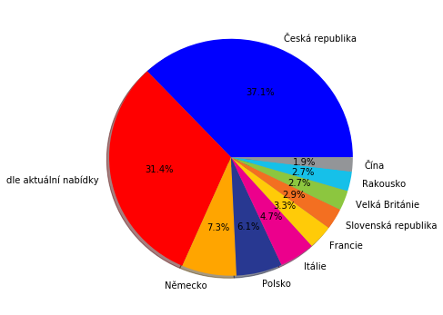

```python
c = Counter()
for i in dfProducts["country_of_origin"]:
    c[i] += 1
labels = list(l[0] for l in c.most_common(10))
values = list(l[1] for l in c.most_common(10))
plt.figure(figsize=(6, 6))
plt.pie(values, labels=labels, autopct='%1.1f%%', shadow=True,
colors = [
'blue',
'red',
'orange',
'#283891',
'#ec008c',
'#ffcb08',
'#f36f21',
'#8cc63f',
'#16c0e9',
'#939598'
])
plt.show()
```

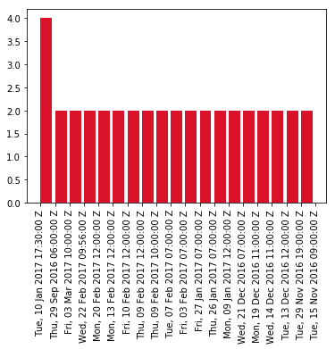

```python
c = Counter()
for i in dfUnionAll["date"]:
  c[i] += 1
labels = list(l[0] for l in c.most_common(20))
values = list(l[1] for l in c.most_common(20))
lab = []
val = []
lab2 = []
val2 = []
for i, j in zip(labels, values):
    if j %2 == 0:
        lab.append(i)
        val.append(j)
plt.bar(range(len(lab)), val, color='#d91129')
plt.axes().set_xticks([j - 0.4 for j in range(len(labels))])
plt.axes().set_xticklabels(labels, rotation=90)
plt.show()
```